# PracticalMachineLearning_Project

Yuqi Wang

9/15/2017

## Introduction

This is my R markdown document for the project in Practical Machine Learning. Thank you for the time and efforts in reviewing my document.  
#Background Using devices such as Jawbone Up, Nike FuelBand, and Fitbit it is now possible to collect a large amount of data about personal activity relatively inexpensively. These type of devices are part of the quantified self movement – a group of enthusiasts who take measurements about themselves regularly to improve their health, to find patterns in their behavior, or because they are tech geeks. One thing that people regularly do is quantify how much of a particular activity they do, but they rarely quantify how well they do it. In this project, your goal will be to use data from accelerometers on the belt, forearm, arm, and dumbell of 6 participants. They were asked to perform barbell lifts correctly and incorrectly in 5 different ways. More information is available from the website [here](http://groupware.les.inf.puc-rio.br/har). (see the section on the Weight Lifting Exercise Dataset).

# Data

The training data for this project are available [here](https://d396qusza40orc.cloudfront.net/predmachlearn/pml-training.csv)  
The test data are available [here](https://d396qusza40orc.cloudfront.net/predmachlearn/pml-testing.csv)  
The data for this project come from this [source](http://groupware.les.inf.puc-rio.br/har). If you use the document you create for this class for any purpose please cite them as they have been very generous in allowing their data to be used for this kind of assignment.

# Goal

The goal of the project is to predict the manner in which they did the exercise. This is the “classe” variable in the training set. You may use any of the other variables to predict with. You should create a report describing how you built your model, how you used cross validation, what you think the expected out of sample error is, and why you made the choices you did. You will also use your prediction model to predict 20 different test cases.

## Data Loading

Set up the library loading and seed for the run.

```r
library(caret)
library(rpart)
library(rpart.plot)
library(RColorBrewer)
library(randomForest)
set.seed(98765)
```

Download the training and testing datasets and load to R. Partition the training dataset to training and testing.

```r
download.file(url = "https://d396qusza40orc.cloudfront.net/predmachlearn/pml-training.csv",
    destfile = "./training_data.csv", method = "curl")
download.file(url = "https://d396qusza40orc.cloudfront.net/predmachlearn/pml-testing.csv",
    destfile = "./testing_data.csv", method = "curl")
training_set <- read.csv("training_data.csv", header = TRUE, sep = ",", na.strings = c("NA",
    "#DIV/0!", ""))
testing_set <- read.csv("testing_data.csv", header = TRUE, sep = ",", na.strings = c("NA",
    "#DIV/0!", ""))
```

## Data Preprocessing

Remove all of the near zero variance column, row ID column and clean the variables that have more than 50% NA’s.

```r
# remove the near zero variance columns
str(training_set)
```

[output not shown]

[output cut: 86 more lines]

```r
nearzeroind_train <- nearZeroVar(training_set, saveMetrics = TRUE)
training_set <- training_set[, nearzeroind_train$nzv == FALSE]
# remove the row ID column
training_set <- training_set[c(-1)]
testing_set <- testing_set[c(-1)]
# clean the variables that have more than 50% NA's
drop_list <- rep(0, ncol(training_set))
for (i in 1:ncol(training_set)) {
    if (sum(is.na(training_set[, i]))/nrow(training_set) >= 0.5) {
        drop_list[i] <- i
    }
}
drop_list <- drop_list[drop_list != 0]
training_set <- training_set[c(-drop_list)]
final_list <- names(training_set)
final_list
```

```
##  [1] "user_name"            "raw_timestamp_part_1" "raw_timestamp_part_2"
##  [4] "cvtd_timestamp"       "num_window"           "roll_belt"
##  [7] "pitch_belt"           "yaw_belt"             "total_accel_belt"
## [10] "gyros_belt_x"         "gyros_belt_y"         "gyros_belt_z"
## [13] "accel_belt_x"         "accel_belt_y"         "accel_belt_z"
## [16] "magnet_belt_x"        "magnet_belt_y"        "magnet_belt_z"
## [19] "roll_arm"             "pitch_arm"            "yaw_arm"
## [22] "total_accel_arm"      "gyros_arm_x"          "gyros_arm_y"
## [25] "gyros_arm_z"          "accel_arm_x"          "accel_arm_y"
## [28] "accel_arm_z"          "magnet_arm_x"         "magnet_arm_y"
## [31] "magnet_arm_z"         "roll_dumbbell"        "pitch_dumbbell"
## [34] "yaw_dumbbell"         "total_accel_dumbbell" "gyros_dumbbell_x"
## [37] "gyros_dumbbell_y"     "gyros_dumbbell_z"     "accel_dumbbell_x"
## [40] "accel_dumbbell_y"     "accel_dumbbell_z"     "magnet_dumbbell_x"
## [43] "magnet_dumbbell_y"    "magnet_dumbbell_z"    "roll_forearm"
## [46] "pitch_forearm"        "yaw_forearm"          "total_accel_forearm"
## [49] "gyros_forearm_x"      "gyros_forearm_y"      "gyros_forearm_z"
## [52] "accel_forearm_x"      "accel_forearm_y"      "accel_forearm_z"
## [55] "magnet_forearm_x"     "magnet_forearm_y"     "magnet_forearm_z"
## [58] "classe"
```

```r
testing_set <- testing_set[, c(final_list[1:(ncol(training_set) - 1)])]

# match the data type from testing data to training data
for (i in 1:ncol(testing_set)) {
    for (j in 1:ncol(training_set)) {
        if (length(grep(names(training_set[i]), names(testing_set)[j])) == 1) {
            class(testing_set[j]) <- class(training_set[i])
        }
    }
}
testing_set <- rbind(training_set[1, -58], testing_set)
testing_set <- testing_set[-1, ]
# partition the training dataset to create testing dataset
inTrain <- createDataPartition(training_set$classe, p = 0.75, list = FALSE)
training <- training_set[inTrain, ]
testing <- training_set[-inTrain, ]
dim(training)
```

```
## [1] 14718    58
```

```r
dim(testing)
```

```
## [1] 4904   58
```

```r
dim(testing_set)
```

```
## [1] 20 57
```

## Model Building with training data

# Random Forest

```r
fit_rf <- randomForest(classe ~ ., data = training)
pred_rf <- predict(fit_rf, testing, type = "class")
confusionMatrix(pred_rf, testing$classe)
```

```
## Confusion Matrix and Statistics
##
##           Reference
## Prediction    A    B    C    D    E
##          A 1395    0    0    0    0
##          B    0  949    0    0    0
##          C    0    0  855    1    0
##          D    0    0    0  803    0
##          E    0    0    0    0  901
##
## Overall Statistics
##
##                Accuracy : 0.9998
##                  95% CI : (0.9989, 1)
##     No Information Rate : 0.2845
##     P-Value [Acc > NIR] : < 2.2e-16
##
##                   Kappa : 0.9997
##  Mcnemar's Test P-Value : NA
##
## Statistics by Class:
##
##                      Class: A Class: B Class: C Class: D Class: E
## Sensitivity            1.0000   1.0000   1.0000   0.9988   1.0000
## Specificity            1.0000   1.0000   0.9998   1.0000   1.0000
## Pos Pred Value         1.0000   1.0000   0.9988   1.0000   1.0000
## Neg Pred Value         1.0000   1.0000   1.0000   0.9998   1.0000
## Prevalence             0.2845   0.1935   0.1743   0.1639   0.1837
## Detection Rate         0.2845   0.1935   0.1743   0.1637   0.1837
## Detection Prevalence   0.2845   0.1935   0.1746   0.1637   0.1837
## Balanced Accuracy      1.0000   1.0000   0.9999   0.9994   1.0000
```

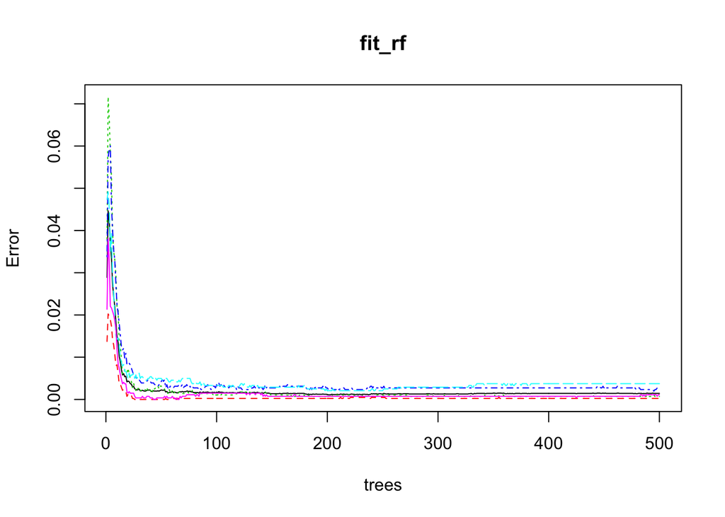

```r
plot(fit_rf)
```

# Decision Tree

```r
fit_dt <- rpart(classe ~ ., data = training, method = "class")
pred_dt <- predict(fit_dt, testing, type = "class")
confusionMatrix(pred_dt, testing$classe)
```

```
## Confusion Matrix and Statistics
##
##           Reference
## Prediction    A    B    C    D    E
##          A 1341   43    5    0    0
##          B   43  791   44   40    0
##          C   11  107  790  142   42
##          D    0    8    7  472   66
##          E    0    0    9  150  793
##
## Overall Statistics
##
##                Accuracy : 0.8538
##                  95% CI : (0.8436, 0.8636)
##     No Information Rate : 0.2845
##     P-Value [Acc > NIR] : < 2.2e-16
##
##                   Kappa : 0.815
##  Mcnemar's Test P-Value : NA
##
## Statistics by Class:
##
##                      Class: A Class: B Class: C Class: D Class: E
## Sensitivity            0.9613   0.8335   0.9240  0.58706   0.8801
## Specificity            0.9863   0.9679   0.9254  0.98024   0.9603
## Pos Pred Value         0.9654   0.8617   0.7234  0.85353   0.8330
## Neg Pred Value         0.9846   0.9604   0.9829  0.92370   0.9727
## Prevalence             0.2845   0.1935   0.1743  0.16395   0.1837
## Detection Rate         0.2735   0.1613   0.1611  0.09625   0.1617
## Detection Prevalence   0.2832   0.1872   0.2227  0.11277   0.1941
## Balanced Accuracy      0.9738   0.9007   0.9247  0.78365   0.9202
```

[figure not shown]

```r
prp(fit_dt, varlen = 5)
```

## Prediction with Testing

Random forest has an accuracy of 99.98% from the training and testing dataset, which is better than decision tree method. I will implement random forest to predict for the testing dataset.

```r
pred_test <- predict(fit_rf, testing_set, type = "class")
pred_test
```

```
##  2  3  4  5  6  7  8  9 10 11 12 13 14 15 16 17 18 19 20 21
##  B  A  B  A  A  E  D  B  A  A  B  C  B  A  E  E  A  B  B  B
## Levels: A B C D E
```